# Haystack Cluster Analysis Notebook Part 1

# Cluster Analysis - Haystack Data

The notebook uses clean, processes data from Step 3 - Data Augmentation Python notebook ## Part 1 uses Numeric Data Types (see part 2 for mixed data types) ** Load Key Libraries **

```r
library(magrittr)
library(HDclassif)
library(psych)
library(cluster)
library(ggplot2)
library(tidyverse)
library(FactoMineR)
options(scipen=999)
```

### Load data

```r
zdata <- read_csv("zillow_schools_tax_dataV2.csv", col_names = TRUE)
colnames(zdata)
```

```
 [1] "rentZestimate"             "zestimate"
 [3] "price_y"                   "PCT_CHG"
 [5] "bathrooms"                 "bedrooms"
 [7] "yearBuilt"                 "address"
 [9] "city"                      "state"
[11] "zip"                       "latitude"
[13] "longitude"                 "livingArea"
[15] "Lot_Size_SqFt"             "Price_SqFt"
[17] "cap_rate"                  "Tot_Appl"
[19] "Tot_Comm_Feat"             "Page_Views"
[21] "Sch_Rat_Avg"               "Sch_Dist_Avg"
[23] "sch_cnt"                   "Individuals_taxed"
[25] "Income_per_return"         "Cap_gain"
[27] "Pension"                   "UE_claims"
[29] "Social_security"           "SB_income"
[31] "Student_loan_ded"          "RE_taxes"
[33] "PP_taxes"                  "Child_credit"
[35] "Earned_Inc_credit"         "violent_crime_total_rate"
[37] "property_crime_total_rate" "other_crime_total_rate"
[39] "Prop_Cond_Grp_New"         "Prop_Cond_Grp_Remodeled"
[41] "Prop_Cond_Grp_Resale"      "Two_Car_Garage_0"
[43] "Two_Car_Garage_1"          "HasPool_0"
[45] "HasPool_1"                 "HasHardwood_0"
[47] "HasHardwood_1"
```

### Create first data frame that uses all numeric variables including dummy variables

```r
dfz <- zdata%>%select(., rentZestimate,zestimate,
         price_y, PCT_CHG, bathrooms, bedrooms,
         yearBuilt,livingArea,Price_SqFt,
         cap_rate, Tot_Appl,Tot_Comm_Feat,
         Page_Views, Sch_Rat_Avg, Sch_Dist_Avg,
         sch_cnt, Individuals_taxed,
         Income_per_return, Cap_gain, Pension,
         UE_claims, Social_security, SB_income,
         Student_loan_ded, RE_taxes, PP_taxes,
         Child_credit, Earned_Inc_credit,
         violent_crime_total_rate, property_crime_total_rate,
         other_crime_total_rate, Prop_Cond_Grp_New,
         Prop_Cond_Grp_Remodeled, Two_Car_Garage_1,
         HasPool_1, HasHardwood_1)

#summary(dfz)
```

### Prior to PCA we convert dummy variables to logical.

```r
dfz$Prop_Cond_Grp_New <- as.logical(dfz$Prop_Cond_Grp_New)
dfz$Prop_Cond_Grp_Remodeled <- as.logical(dfz$Prop_Cond_Grp_Remodeled)
dfz$Two_Car_Garage_1 <- as.logical(dfz$Two_Car_Garage_1)
dfz$HasPool_1 <- as.logical(dfz$HasPool_1)
dfz$HasHardwood_1 <- as.logical(dfz$HasHardwood_1)
```

### Creating second data frame for FAMD.

Note: Prior to FAMD we convert dummy variables to categorical/factor.

```r
dfz_FAMD<-dfz
dfz_FAMD$Prop_Cond_Grp_New <- as.factor(dfz_FAMD$Prop_Cond_Grp_New)
dfz_FAMD$Prop_Cond_Grp_Remodeled <- as.factor(dfz_FAMD$Prop_Cond_Grp_Remodeled)
dfz_FAMD$Two_Car_Garage_1 <- as.factor(dfz_FAMD$Two_Car_Garage_1)
dfz_FAMD$HasPool_1 <- as.factor(dfz_FAMD$HasPool_1)
dfz_FAMD$HasHardwood_1 <- as.factor(dfz_FAMD$HasHardwood_1)
```

### Create third data frame that uses all numeric variables except dummy variables

```r
dfz_numeric <- zdata%>%select(., rentZestimate,zestimate,
                      price_y, PCT_CHG, bathrooms, bedrooms,
                      yearBuilt,livingArea,Price_SqFt,
                      cap_rate, Tot_Appl,Tot_Comm_Feat,
                      Page_Views, Sch_Rat_Avg, Sch_Dist_Avg,
                      sch_cnt, Individuals_taxed,
                      Income_per_return, Cap_gain, Pension,
                      UE_claims, Social_security, SB_income,
                      Student_loan_ded, RE_taxes, PP_taxes,
                      Child_credit, Earned_Inc_credit,
                      violent_crime_total_rate, property_crime_total_rate,
                      other_crime_total_rate)

#summary(dfz2)
```

## PCA Function

```r
run_pca <- function(data_frame, pca_type, components) {

  if (pca_type == "FAMD") {
    res <- FAMD(data_frame, ncp = components)
    cluster_input <-res$ind$coord
    } else {
      pc <- prcomp(data_frame, center = TRUE, scale. = TRUE)
      cluster_input <- pc$x
      #calculate total variance explained by each principal component
      var_explained = pc$sdev^2 / sum(pc$sdev^2)
      #create scree plot
      qp <- qplot(c(1:components), var_explained) + geom_line() +
        xlab("Principal Component") + ylab("Variance Explained") +
        ggtitle("Scree Plot") + ylim(0, 1)
}

  return(cluster_input)
}
```

## Number of Clusters Function

### Using NbClust we will determine how many clusters are needed given transformed data as input (note: the input data frame should be PCA components or FAMD coordinates)

```r
fun_nc <- function(data_frame, diss_dist, min_clust, max_clust, clus_method) {
  numComplete <- NbClust::NbClust(
    data = data_frame, # this is principal components
    distance = diss_dist, # dissimarlity distance ("euclidean", "maximum",
    #"manhattan", "canberra", "binary", or "minkowski")
    min.nc = min_clust,
    max.nc = max_clust,
    method = clus_method, #"ward.D", "ward.D2", "single", "complete",
    #"average", "mcquitty", "median", "centroid", "kmeans".
    index = "all")
  out_best <- numComplete$Best.nc
  return(out_best)
}
```

### Run an example of cluster analysis using PCA

### Step1: PCA

```r
#run_pca <- function(data_frame, pca_type, components)
dfl_pca <- run_pca(dfz, "PCA")
dfn_pca <- run_pca(dfz_numeric, "PCA")
```

```
*** : The Hubert index is a graphical method of determining the number of clusters.
                In the plot of Hubert index, we seek a significant knee that corresponds to a
                significant increase of the value of the measure i.e the significant peak in Hubert
                index second differences plot.
```

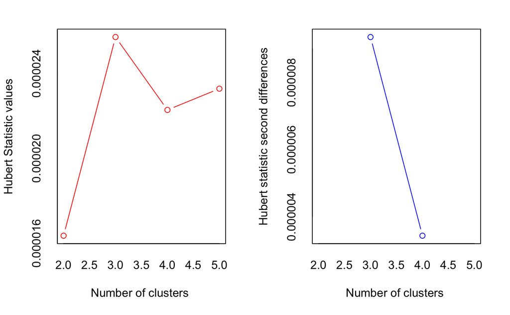

```
*** : The D index is a graphical method of determining the number of clusters.
                In the plot of D index, we seek a significant knee (the significant peak in Dindex
                second differences plot) that corresponds to a significant increase of the value of
                the measure.

* Among all indices:
* 7 proposed 2 as the best number of clusters
* 12 proposed 3 as the best number of clusters
* 2 proposed 5 as the best number of clusters

                   ***** Conclusion *****

* According to the majority rule, the best number of clusters is  3
```

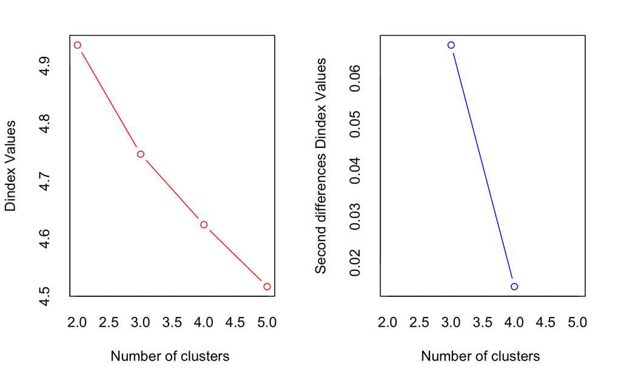

```
*** : The Hubert index is a graphical method of determining the number of clusters.
                In the plot of Hubert index, we seek a significant knee that corresponds to a
                significant increase of the value of the measure i.e the significant peak in Hubert
                index second differences plot.
```

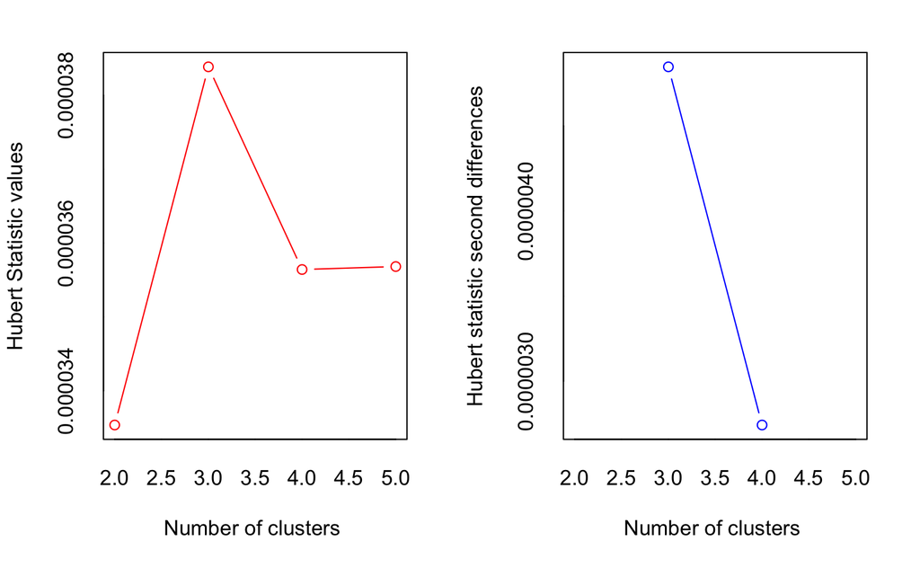

```
*** : The D index is a graphical method of determining the number of clusters.
                In the plot of D index, we seek a significant knee (the significant peak in Dindex
                second differences plot) that corresponds to a significant increase of the value of
                the measure.

* Among all indices:
* 6 proposed 2 as the best number of clusters
* 8 proposed 3 as the best number of clusters
* 4 proposed 4 as the best number of clusters
* 3 proposed 5 as the best number of clusters

                   ***** Conclusion *****

* According to the majority rule, the best number of clusters is  3


[1] "Frey index : No clustering structure in this data set"
```

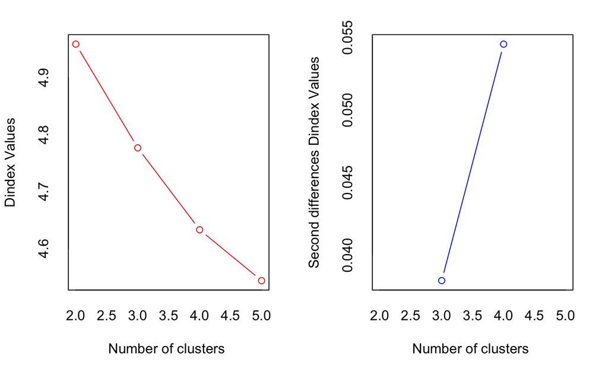

```
*** : The Hubert index is a graphical method of determining the number of clusters.
                In the plot of Hubert index, we seek a significant knee that corresponds to a
                significant increase of the value of the measure i.e the significant peak in Hubert
                index second differences plot.
```

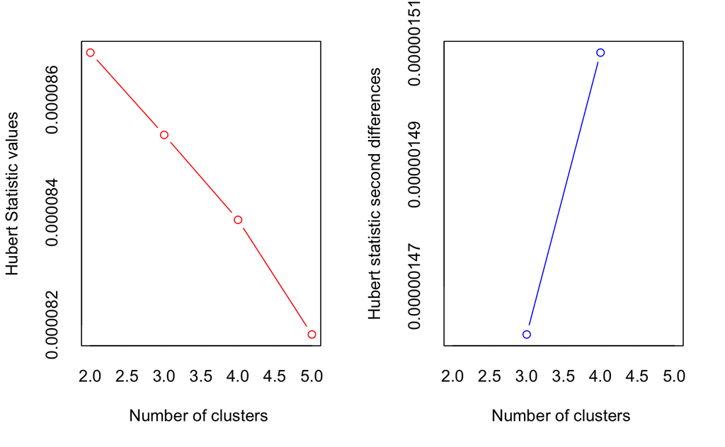

```
*** : The D index is a graphical method of determining the number of clusters.
                In the plot of D index, we seek a significant knee (the significant peak in Dindex
                second differences plot) that corresponds to a significant increase of the value of
                the measure.

* Among all indices:
* 8 proposed 2 as the best number of clusters
* 6 proposed 3 as the best number of clusters
* 3 proposed 4 as the best number of clusters
* 6 proposed 5 as the best number of clusters

                   ***** Conclusion *****

* According to the majority rule, the best number of clusters is  2


[1] "Frey index : No clustering structure in this data set"
```

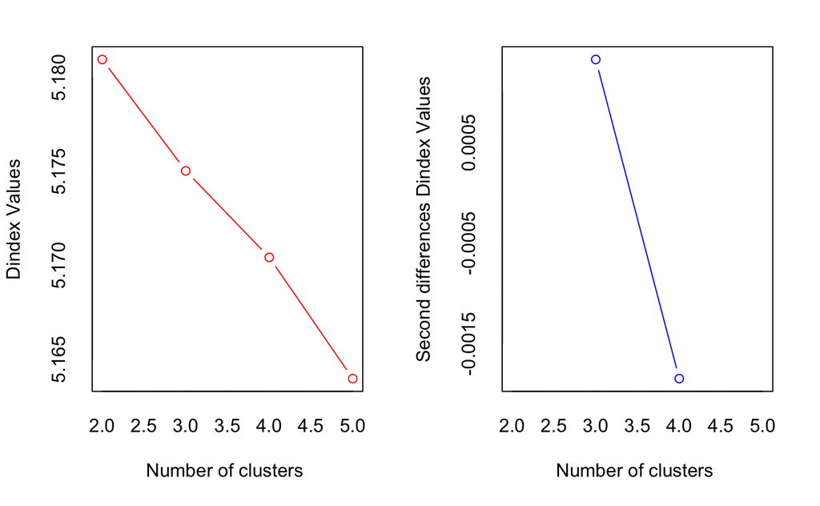

```
*** : The Hubert index is a graphical method of determining the number of clusters.
                In the plot of Hubert index, we seek a significant knee that corresponds to a
                significant increase of the value of the measure i.e the significant peak in Hubert
                index second differences plot.
```

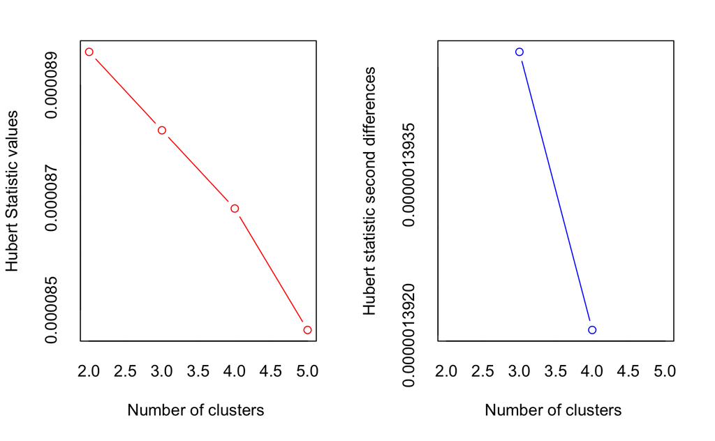

```
*** : The D index is a graphical method of determining the number of clusters.
                In the plot of D index, we seek a significant knee (the significant peak in Dindex
                second differences plot) that corresponds to a significant increase of the value of
                the measure.

* Among all indices:
* 8 proposed 2 as the best number of clusters
* 6 proposed 3 as the best number of clusters
* 6 proposed 4 as the best number of clusters
* 3 proposed 5 as the best number of clusters

                   ***** Conclusion *****

* According to the majority rule, the best number of clusters is  2


[1] "Frey index : No clustering structure in this data set"
```

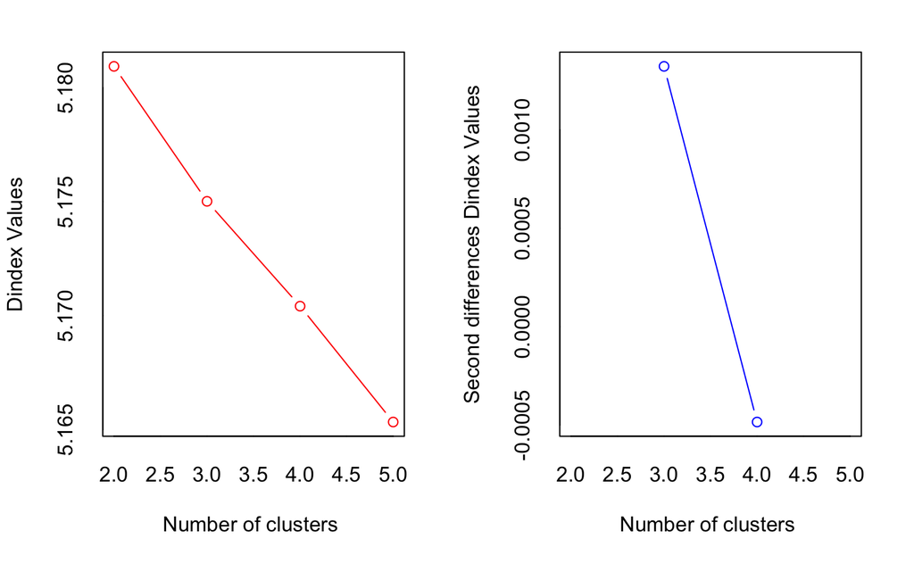

```
*** : The Hubert index is a graphical method of determining the number of clusters.
                In the plot of Hubert index, we seek a significant knee that corresponds to a
                significant increase of the value of the measure i.e the significant peak in Hubert
                index second differences plot.
```

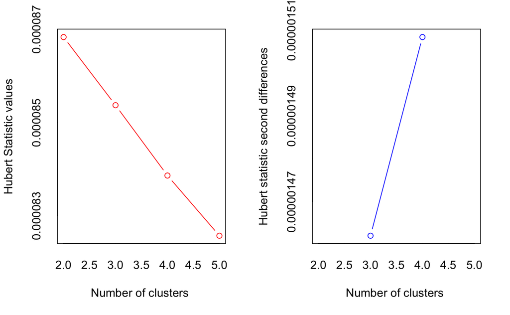

```
*** : The D index is a graphical method of determining the number of clusters.
                In the plot of D index, we seek a significant knee (the significant peak in Dindex
                second differences plot) that corresponds to a significant increase of the value of
                the measure.

* Among all indices:
* 8 proposed 2 as the best number of clusters
* 9 proposed 3 as the best number of clusters
* 4 proposed 4 as the best number of clusters
* 2 proposed 5 as the best number of clusters

                   ***** Conclusion *****

* According to the majority rule, the best number of clusters is  3


[1] "Frey index : No clustering structure in this data set"
```

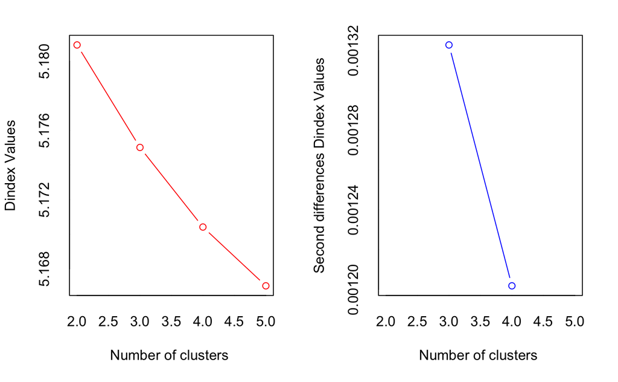

```
*** : The Hubert index is a graphical method of determining the number of clusters.
                In the plot of Hubert index, we seek a significant knee that corresponds to a
                significant increase of the value of the measure i.e the significant peak in Hubert
                index second differences plot.
```

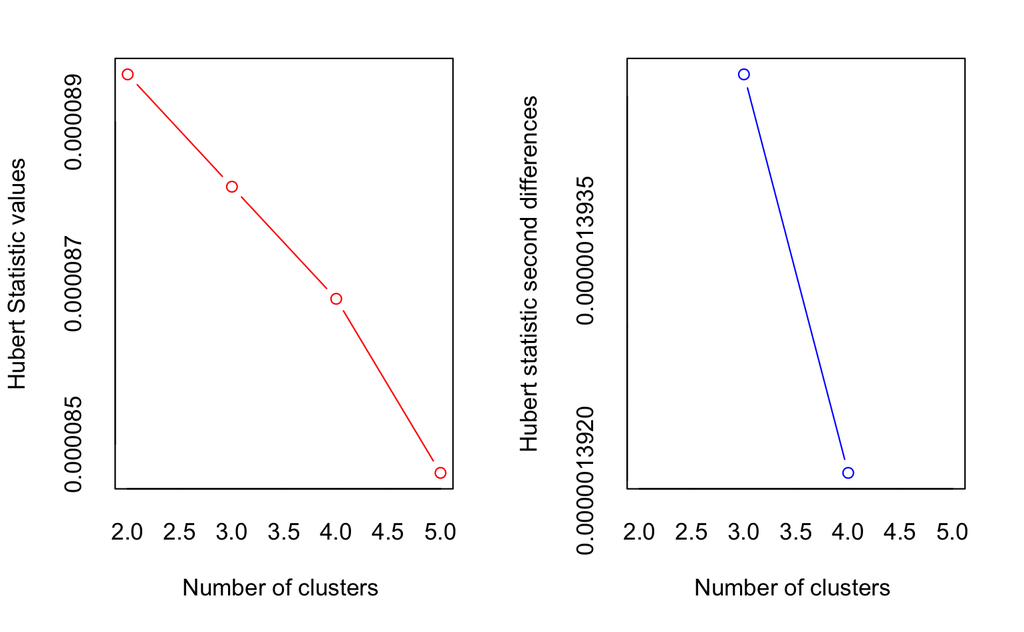

```
*** : The D index is a graphical method of determining the number of clusters.
                In the plot of D index, we seek a significant knee (the significant peak in Dindex
                second differences plot) that corresponds to a significant increase of the value of
                the measure.

* Among all indices:
* 8 proposed 2 as the best number of clusters
* 6 proposed 3 as the best number of clusters
* 6 proposed 4 as the best number of clusters
* 3 proposed 5 as the best number of clusters

                   ***** Conclusion *****

* According to the majority rule, the best number of clusters is  2
```

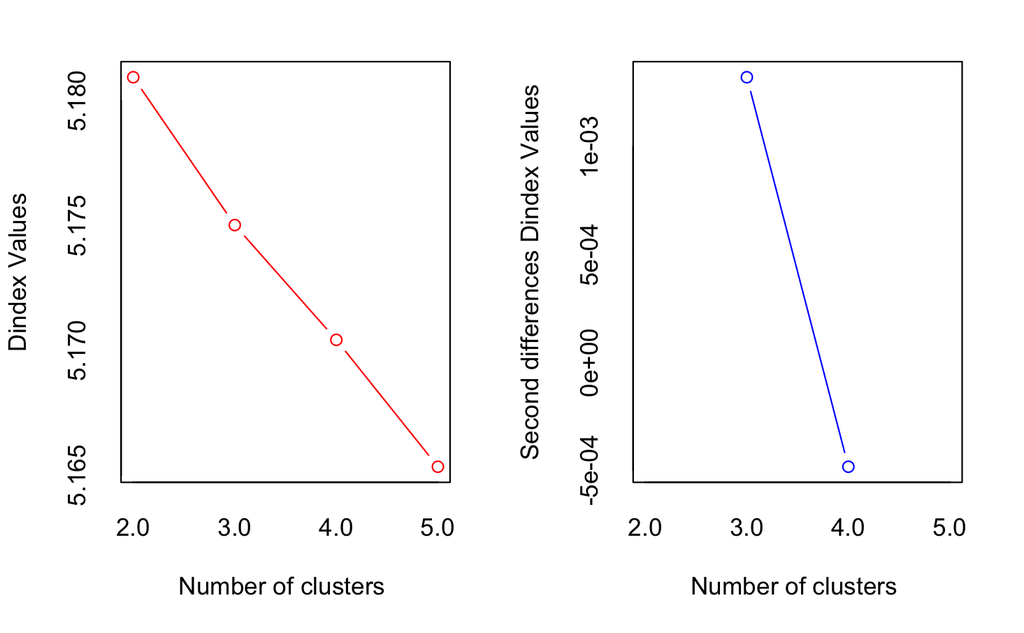

```r
meth_list <- list("ward.D", "centroid","median")#, "average", "median", "centroid")
dist_list <- list("minkowski","maximum")#,"canberra")
bclist <- list()
# loop
for (m in meth_list) {
  for (d in dist_list){
    best_cluster <- fun_nc(dfn_pca, d, 2, 5, m)
    #bclist  <- c(bclist, best_cluster)
    bclist[[length(bclist) + 1]] <- best_cluster
  }
}
```

Evaluate number of clusters and value index

```r
#use the list to inspect results
bclist[1]
```

```
[[1]]
                    KL       CH Hartigan      CCC    Scott
Number_clusters 3.0000   2.0000   3.0000   2.0000    3.000
Value_Index     2.5749 473.8966 198.8916 -34.7166 3819.551
                                                                                                                Marriot
Number_clusters                                                                                                       3
Value_Index     9776435617425761422544252366640813449446244107420678844508157626468477385740152256289930146150606700544
                  TrCovW   TraceW Friedman   Rubin Cindex     DB Silhouette Duda
Number_clusters        3    3.000   3.0000  3.0000 3.0000 2.0000     2.0000   NA
Value_Index     10645102 5349.774   1.5538 -0.0439 0.1486 2.0829     0.1267   NA
                PseudoT2 Beale Ratkowsky     Ball PtBiserial Frey McClain   Dunn
Number_clusters       NA  3.00    5.0000     3.00     3.0000    1  2.0000 2.0000
Value_Index           NA  1.25    0.0816 24870.57     0.2716   NA  0.2994 0.0307
                Hubert SDindex Dindex   SDbw
Number_clusters      0  2.0000      0 5.0000
Value_Index          0  1.0383      0 0.6451
```

### Step 3: Setting up the Hierarchical Clustering Aproach

#### We define a gobal function that can output clusters using various distances, methods

```r
fun_clust <- function(data_frame, distance, agglo_method, clusters) {
  # use a distance metric such as "euclidean", "maximum",
  # "canberra", or "minkowski"
  fdistance <- dist(data_frame, method=distance)
  # The agglomeration method: ward.D", "ward.D2",
  # "median" (= WPGMC) or "centroid" (= UPGMC).
  hc_complete <- hclust(fdistance, method = agglo_method)
  # Plotting a dendogram
  dend_complete <- as.dendrogram(hc_complete)
  dend1 <- dendextend::color_branches(dend_complete, k = 3)
  plot(dend1, main = "Complete-Linkage")

  clusters <- cutree(hc_complete, clusters)
  cluster_dist <- table(clusters)

  return(clusters)
}
```

Step 4: Execute the cluserting using dfn_pca

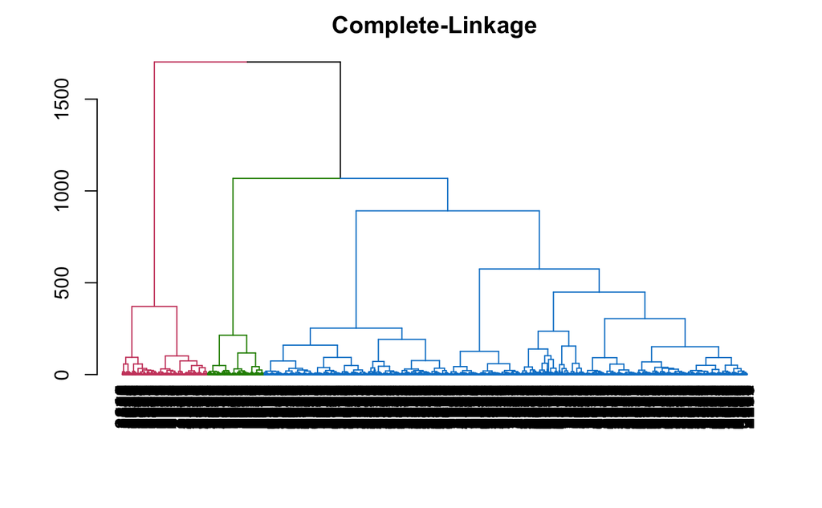

```r
#fun_clust <- function(data_frame, distance, agglo_method, clusters)
pca_max_ward_num <- fun_clust(dfn_pca, "maximum", "ward.D", 5)
```

Evaluate Clusters

```r
table(pca_max_ward_num)
```

```
pca_max_ward_num
   1    2    3    4    5
1662 1362  414  525  628
```

```r
library(ggplot2)
tmp_data <- zdata
tmp_data$cluster <-pca_max_ward_num
tmp_data$cluster <- as.factor(tmp_data$cluster)
p <- ggplot(tmp_data, aes(x=cluster, y=rentZestimate)) +
  geom_boxplot()
p
q <- ggplot(tmp_data, aes(x=cluster, y=Sch_Rat_Avg)) +
  geom_boxplot()
q
```

[output not shown]

```r
p <- ggplot(tmp_data, aes(x=cluster, y=Income_per_return)) +
  geom_boxplot()
p
q <- ggplot(tmp_data, aes(x=cluster, y=violent_crime_total_rate)) +
  geom_boxplot()
q
```

[output not shown]

### Step 5: Save the data to a file for exploratory analysis

```r
tmp_data$ClusterCategory <- ifelse(tmp_data$cluster == 1, "Cluster 1",
                              ifelse(tmp_data$cluster == 2, "Cluster 2",
                                     ifelse(tmp_data$cluster == 3, "Cluster 3",
                                            ifelse(tmp_data$cluster == 4, "Cluster 4",
                                     "Cluster 5"))))
```

### We will add autoencoder results to the 5 clusters as part of anamoly detection

```r
library("h2o")
h2o.init()
```

```
 Connection successful!

R is connected to the H2O cluster:
    H2O cluster uptime:         2 hours 32 minutes
    H2O cluster timezone:       America/New_York
    H2O data parsing timezone:  UTC
    H2O cluster version:        3.38.0.1
    H2O cluster version age:    25 days
    H2O cluster name:           H2O_started_from_R_nimitsharma_xuq038
    H2O cluster total nodes:    1
    H2O cluster total memory:   1.99 GB
    H2O cluster total cores:    8
    H2O cluster allowed cores:  8
    H2O cluster healthy:        TRUE
    H2O Connection ip:          localhost
    H2O Connection port:        54321
    H2O Connection proxy:       NA
    H2O Internal Security:      FALSE
    R Version:                  R version 4.2.1 (2022-06-23)
```

```r
model=h2o.deeplearning(1:10,
                  training_frame=as.h2o(dfn_pca),
                  hidden=c(10,5,10),
                  epochs = 100,
                  autoencoder = T,
                  activation="Tanh")
summary(model)
```

```
Model Details:
==============

H2OAutoEncoderModel: deeplearning
Model Key:  DeepLearning_model_R_1665839151366_9
Status of Neuron Layers: auto-encoder, gaussian distribution, Quadratic loss, 335 weights/biases, 9.1 KB, 459,100 training samples, mini-batch size 1
```

|  | layer | units | type | dropout | l1 | l2 | mean_rate | rate_rms | momentum | mean_weight | weight_rms | mean_bias | bias_rms |
| --- | --- | --- | --- | --- | --- | --- | --- | --- | --- | --- | --- | --- | --- |
| 1 | 1 | 10 | Input | 0.00 % | NA | NA | NA | NA | NA | NA | NA | NA | NA |
| 2 | 2 | 10 | Tanh | 0.00 % | 0.000000 | 0.000000 | 0.362132 | 0.261417 | 0.000000 | 0.020094 | 0.455480 | -0.154992 | 0.397932 |
| 3 | 3 | 5 | Tanh | 0.00 % | 0.000000 | 0.000000 | 0.062783 | 0.023664 | 0.000000 | 0.023646 | 0.405187 | 0.080972 | 0.219636 |
| 4 | 4 | 10 | Tanh | 0.00 % | 0.000000 | 0.000000 | 0.062722 | 0.028290 | 0.000000 | -0.068112 | 0.443282 | 0.032165 | 0.351706 |
| 5 | 5 | 10 | Tanh | NA | 0.000000 | 0.000000 | 0.030599 | 0.020376 | 0.000000 | 0.012386 | 0.205481 | -0.023237 | 0.226084 |

```
H2OAutoEncoderMetrics: deeplearning
** Reported on training data. **

Training Set Metrics:
=====================

MSE: (Extract with `h2o.mse`) 0.001417373
RMSE: (Extract with `h2o.rmse`) 0.03764802






Scoring History:
```

|  | timestamp | duration | training_speed | epochs | iterations | samples | training_rmse | training_mse |
| --- | --- | --- | --- | --- | --- | --- | --- | --- |
| 1 | 2022-10-15 11:38:31 | 0.062 sec | 0.00000 obs/sec | 0.00000 | 0 | 0.000000 | 0.11748 | 0.01380 |
| 2 | 2022-10-15 11:38:33 | 1.541 sec | 312738 obs/sec | 100.00000 | 10 | 459100.000000 | 0.03765 | 0.00142 |

```
Variable Importances: (Extract with `h2o.varimp`)
=================================================

Variable Importances:
```

|  | variable | relative_importance | scaled_importance | percentage |
| --- | --- | --- | --- | --- |
| 1 | PC3 | 1.000000 | 1.000000 | 0.135536 |
| 2 | PC4 | 0.973848 | 0.973848 | 0.131992 |
| 3 | PC1 | 0.908124 | 0.908124 | 0.123084 |
| 4 | PC10 | 0.896807 | 0.896807 | 0.121550 |
| 5 | PC5 | 0.860374 | 0.860374 | 0.116612 |
| 6 | PC2 | 0.847765 | 0.847765 | 0.114903 |
| 7 | PC6 | 0.585431 | 0.585431 | 0.079347 |
| 8 | PC7 | 0.576226 | 0.576226 | 0.078100 |
| 9 | PC8 | 0.371302 | 0.371302 | 0.050325 |
| 10 | PC9 | 0.358219 | 0.358219 | 0.048552 |

```r
pred.oc <- as.data.frame(h2o.anomaly(model, as.h2o(dfn_pca)))
head(pred.oc)
```

|  | Reconstruction.MSE |
| --- | --- |
| 1 | 0.0016127398 |
| 2 | 0.0006926864 |
| 3 | 0.0049670813 |
| 4 | 0.0010513917 |
| 5 | 0.0025156973 |
| 6 | 0.0001846123 |

```r
tmp_data$ae_mse <-pred.oc$Reconstruction.MSE
```

### Export data to csv

```r
write.csv(tmp_data,"cluster_output_5cls.csv", row.names = FALSE)
```

### Remove the temporary dataset

```r
rm(tmp_data)
```

### Extra evaluation using Random Forest and PAM

```r
rf <- randomForest::randomForest(x = dfl_pca, ntree = 2000, proximity = T)

rf
```

```
Call:
 randomForest(x = dfl_pca, ntree = 2000, proximity = T)
               Type of random forest: unsupervised
                     Number of trees: 2000
No. of variables tried at each split: 6
```

```r
dim(rf$proximity)
```

```
[1] 4591 4591
```

```r
rf$proximity[1:5, 1:5]
```

```
            [,1]        [,2]       [,3]        [,4]        [,5]
[1,] 1.000000000 0.020325203 0.03225806 0.180769231 0.003745318
[2,] 0.020325203 1.000000000 0.09259259 0.039840637 0.003802281
[3,] 0.032258065 0.092592593 1.00000000 0.010752688 0.016722408
[4,] 0.180769231 0.039840637 0.01075269 1.000000000 0.003731343
[5,] 0.003745318 0.003802281 0.01672241 0.003731343 1.000000000
```

```r
randomForest::importance(rf)
```

```
     MeanDecreaseGini
PC1         180.98296
PC2         130.06685
PC3         157.81777
PC4         169.63048
PC5         106.38582
PC6         161.91576
PC7         128.67740
PC8         131.26701
PC9         179.07965
PC10        172.33277
PC11        138.43523
PC12        176.18398
PC13        156.12151
PC14        130.75819
PC15        132.72159
PC16        126.87487
PC17        104.42873
PC18        120.92383
PC19        100.68501
PC20        118.47271
PC21         82.10933
PC22        115.77392
PC23        111.89193
PC24         90.16665
PC25         98.84937
PC26         89.93203
PC27        108.18623
PC28        105.97606
PC29        149.03257
PC30        116.62295
PC31         97.70723
PC32        106.01756
PC33        136.20038
PC34        127.96373
PC35        127.34124
PC36        103.00104
```

```r
set.seed(1776)
rf_dist <- sqrt(1- rf$proximity)
pam_rf <- cluster::pam(rf_dist, k = 3)
table(pam_rf$clustering)
```

```
   1    2    3
3346  864  381
```

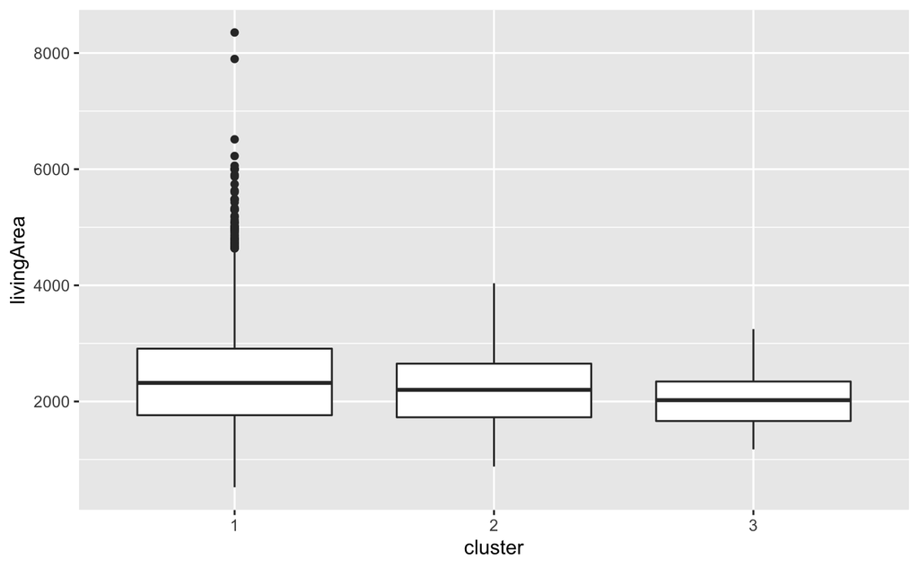

```r
library(ggplot2)
tmp_data <- zdata
tmp_data$cluster <-pam_rf$clustering
tmp_data$cluster <- as.factor(tmp_data$cluster)
p <- ggplot(tmp_data, aes(x=cluster, y=livingArea)) +
  geom_boxplot()
p
```

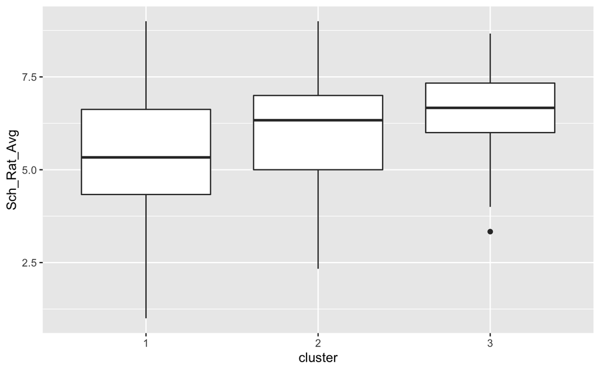

```r
q <- ggplot(tmp_data, aes(x=cluster, y=Sch_Rat_Avg)) +
  geom_boxplot()
q
```

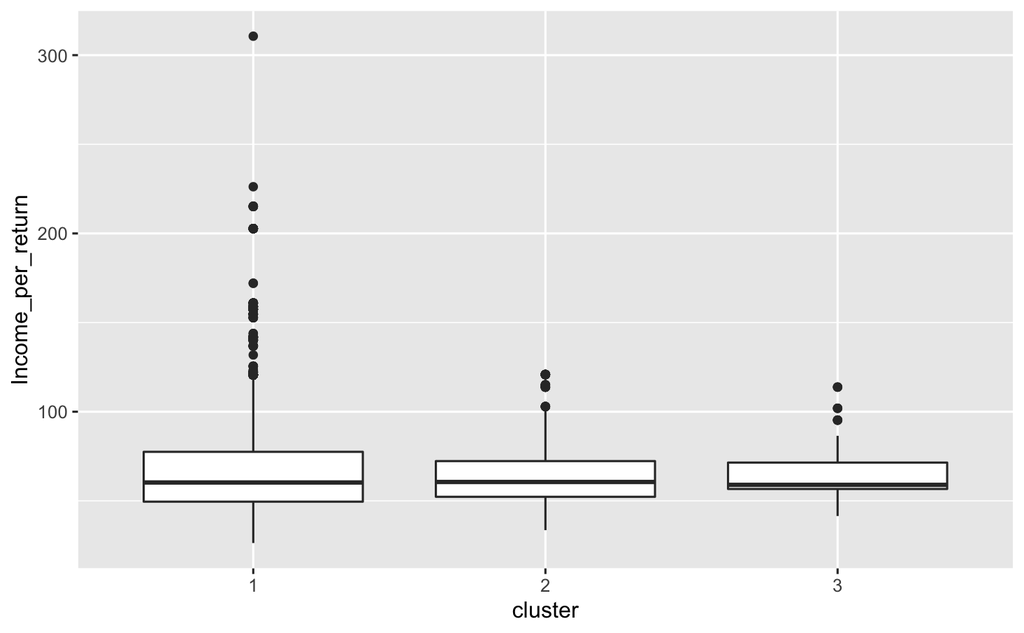

```r
p <- ggplot(tmp_data, aes(x=cluster, y=Income_per_return)) +
  geom_boxplot()
p
```

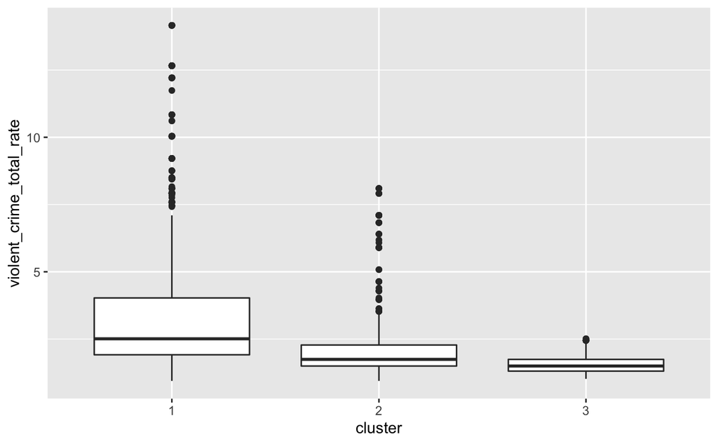

```r
q <- ggplot(tmp_data, aes(x=cluster, y=violent_crime_total_rate)) +
  geom_boxplot()
q
```